# Walmart Sales Analysis: Electronics vs Appliances (EDA)

Pablo

2026-03-01

```r
knitr::opts_chunk$set(echo=TRUE, message=FALSE, warning=FALSE)
library(tidyverse)
library(lubridate)
library(janitor)
library(effsize)
```

```r
walmart <- read_csv("Walmart.csv") |> clean_names()
glimpse(walmart)
```

```
## Rows: 5,000
## Columns: 28
## $ transaction_id         <dbl> 1, 2, 3, 4, 5, 6, 7, 8, 9, 10, 11, 12, 13, 14, …
## $ customer_id            <dbl> 2824, 1409, 5506, 5012, 4657, 3286, 2679, 9935,…
## $ product_id             <dbl> 843, 135, 391, 710, 116, 630, 238, 409, 106, 40…
## $ product_name           <chr> "Fridge", "TV", "Fridge", "Smartphone", "Laptop…
## $ category               <chr> "Electronics", "Electronics", "Electronics", "E…
## $ quantity_sold          <dbl> 3, 4, 4, 5, 3, 4, 3, 4, 4, 5, 3, 3, 2, 3, 2, 4,…
## $ unit_price             <dbl> 188.46, 1912.04, 1377.75, 182.31, 499.28, 1465.…
## $ transaction_date       <chr> "3/31/2024 21:46", "7/28/2024 12:45", "6/10/202…
## $ store_id               <dbl> 3, 5, 1, 5, 6, 1, 3, 16, 12, 10, 12, 9, 3, 13, …
## $ store_location         <chr> "Miami, FL", "Dallas, TX", "Los Angeles, CA", "…
## $ inventory_level        <dbl> 246, 43, 411, 452, 412, 196, 24, 125, 103, 424,…
## $ reorder_point          <dbl> 116, 70, 94, 87, 99, 80, 52, 92, 129, 88, 135, …
## $ reorder_quantity       <dbl> 170, 212, 252, 112, 177, 210, 287, 178, 172, 25…
## $ supplier_id            <dbl> 474, 135, 475, 118, 155, 169, 250, 248, 368, 49…
## $ supplier_lead_time     <dbl> 8, 4, 2, 7, 4, 4, 3, 5, 4, 1, 9, 8, 3, 5, 5, 8,…
## $ customer_age           <dbl> 29, 34, 69, 47, 70, 40, 54, 57, 64, 24, 67, 25,…
## $ customer_gender        <chr> "Other", "Other", "Other", "Other", "Female", "…
## $ customer_income        <dbl> 98760.83, 69781.93, 77373.10, 33383.04, 108999.…
## $ customer_loyalty_level <chr> "Silver", "Gold", "Platinum", "Silver", "Bronze…
## $ payment_method         <chr> "Credit Card", "Cash", "Cash", "Cash", "Digital…
## $ promotion_applied      <lgl> TRUE, TRUE, FALSE, TRUE, FALSE, TRUE, FALSE, FA…
## $ promotion_type         <chr> "None", "Percentage Discount", "None", "Percent…
## $ weather_conditions     <chr> "Stormy", "Rainy", "Sunny", "Sunny", "Sunny", "…
## $ holiday_indicator      <lgl> FALSE, FALSE, FALSE, TRUE, FALSE, TRUE, FALSE, …
## $ weekday                <chr> "Friday", "Monday", "Tuesday", "Sunday", "Thurs…
## $ stockout_indicator     <lgl> TRUE, TRUE, TRUE, FALSE, TRUE, FALSE, TRUE, TRU…
## $ forecasted_demand      <dbl> 172, 109, 289, 174, 287, 294, 178, 165, 476, 39…
## $ actual_demand          <dbl> 179, 484, 416, 446, 469, 265, 257, 264, 428, 40…
```

```r
walmart <- read_csv("Walmart.csv") |> clean_names()
```

1. Data Import and Setup

We begin by loading the necessary packages for data manipulation (tidyverse, dplyr), date handling (lubridate), cleaning variable names (janitor), and effect size computation (effsize). These packages allow us to perform structured exploratory data analysis and hypothesis testing.

The dataset Walmart.csv is imported and cleaned using clean_names() to standardize column naming conventions. The glimpse() function is used to inspect variable types and overall structure of the dataset.

```r
walmart <- walmart %>%
  mutate(
    transaction_date = lubridate::mdy_hm(transaction_date),
    transaction_day  = as.Date(transaction_date)
  )
```

```r
walmart$revenue <- walmart$quantity_sold * walmart$unit_price
```

```r
table(walmart$category)
```

```
##
##  Appliances Electronics
##        2415        2585
```

```r
prop.table(table(walmart$category))
```

```
##
##  Appliances Electronics
##       0.483       0.517
```

```r
library(dplyr)
```

Category Distribution Interpretation

The dataset contains 5,000 total transactions. Electronics account for 51.7% of transactions, while Appliances represent 48.3%. The distribution is relatively balanced, which strengthens the validity of subsequent statistical comparisons. Because the sample sizes are similar, any observed differences in revenue or quantity sold are unlikely to be driven by unequal representation across categories.

```r
walmart %>%
  group_by(category) %>%
  summarise(
    total_revenue = sum(revenue),
    mean_revenue = mean(revenue),
    median_revenue = median(revenue),
    sd_revenue = sd(revenue),
    mean_quantity = mean(quantity_sold),
    n_transactions = n()
  )
```

```
## # A tibble: 2 × 7
##   category    total_revenue mean_revenue median_revenue sd_revenue mean_quantity
##   <chr>               <dbl>        <dbl>          <dbl>      <dbl>         <dbl>
## 1 Appliances       7321970.        3032.          2322.      2368.          2.97
## 2 Electronics      7941632.        3072.          2440.      2374.          3.00
## # ℹ 1 more variable: n_transactions <int>
```

With this in mind now I create a boxplot of revenue by category to compare medians and visualize any outliers.

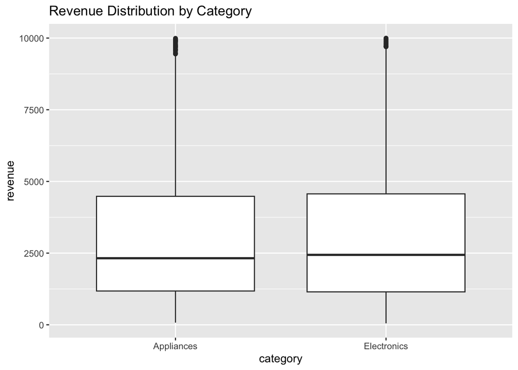

```r
ggplot(walmart, aes(x = category, y = revenue)) +
  geom_boxplot() +
  labs(title = "Revenue Distribution by Category")
```

The boxplot reveals substantial overlap in revenue distributions between Electronics and Appliances. While Electronics appear to have a slightly higher median transaction value, the interquartile ranges overlap considerably, suggesting that typical transaction-level spending is similar across categories.

Both categories display several high-value outliers, indicating occasional large purchases. However, these extreme observations do not appear concentrated in one category, reinforcing the notion that revenue behavior is broadly comparable.

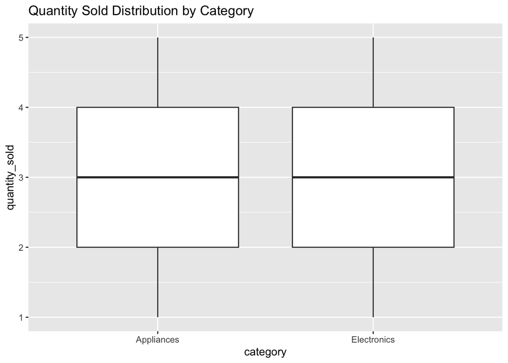

```r
ggplot(walmart, aes(x = category, y = quantity_sold)) +
  geom_boxplot() +
  labs(title = "Quantity Sold Distribution by Category")
```

Quantity Sold Distribution Analysis

The boxplot for quantity sold shows nearly identical distributions between Appliances and Electronics. The median quantity for both categories is approximately three units per transaction, and the interquartile ranges are almost perfectly aligned.

There is no visible evidence of systematic differences in purchase volume across categories. This suggests that customers tend to buy similar quantities regardless of whether they are purchasing Electronics or Appliances.

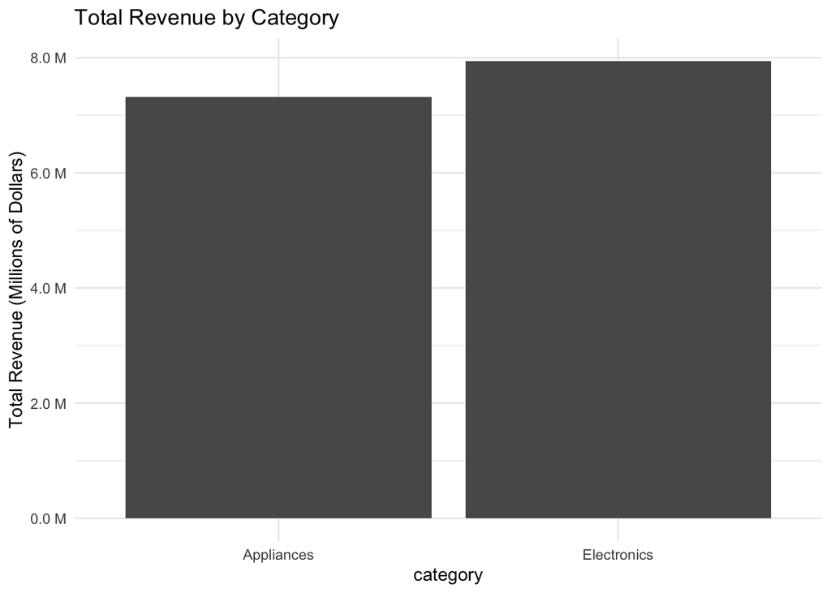

```r
ggplot(walmart %>%
         group_by(category) %>%
         summarise(total_revenue = sum(revenue)),
       aes(x = category, y = total_revenue)) +
  geom_col() +
  scale_y_continuous(
    labels = scales::label_number(
      scale = 1e-6,
      accuracy = 0.1,
      suffix = " M"
    )
  ) +
  labs(
    title = "Total Revenue by Category",
    y = "Total Revenue (Millions of Dollars)"
  ) +
  theme_minimal()
```

Slightly higher transaction frequency (Electronics account for 51.7% of transactions),

Marginally higher average transaction value,

Or small cumulative differences across many transactions.

Importantly, because per-transaction differences were not statistically significant, the aggregate revenue gap appears to reflect scale effects rather than fundamentally different customer purchasing behavior.

```r
t.test(revenue ~ category, data = walmart)
```

```
##
##  Welch Two Sample t-test
##
## data:  revenue by category
## t = -0.60097, df = 4976.6, p-value = 0.5479
## alternative hypothesis: true difference in means between group Appliances and group Electronics is not equal to 0
## 95 percent confidence interval:
##  -171.87764   91.22465
## sample estimates:
##  mean in group Appliances mean in group Electronics
##                  3031.871                  3072.198
```

Hypotheses

H0: mu appliances equeal mu electronics HA: mu appliances not equal mu electronics

The null hypothesis states that there is no difference in mean transaction revenue between Appliances and Electronics. The alternative hypothesis states that the mean transaction revenues are different between the two categories.

At a 5% significance level, we fail to reject the null hypothesis. The p-value (0.548) is substantially greater than 0.05, indicating insufficient evidence to conclude that mean transaction revenue differs between Appliances and Electronics.

Although Electronics show a slightly higher average revenue per transaction, the observed difference is small relative to the variability in revenue and is not statistically significant. Therefore, the data do not provide evidence of a meaningful difference in transaction-level spending between the two categories.

```r
t.test(quantity_sold ~ category, data = walmart)
```

```
##
##  Welch Two Sample t-test
##
## data:  quantity_sold by category
## t = -0.6874, df = 4984.1, p-value = 0.4919
## alternative hypothesis: true difference in means between group Appliances and group Electronics is not equal to 0
## 95 percent confidence interval:
##  -0.10631955  0.05111654
## sample estimates:
##  mean in group Appliances mean in group Electronics
##                  2.968530                  2.996132
```

Null Hypothesis (H0): The mean quantity sold per transaction for Appliances is equal to the mean quantity sold per transaction for Electronics.

Alternative Hypothesis (H1): The mean quantity sold per transaction for Appliances is not equal to the mean quantity sold per transaction for Electronics.

At a 5% significance level, we fail to reject the null hypothesis. The p-value (0.492) is greater than 0.05, indicating insufficient evidence to conclude that the mean quantity sold per transaction differs between Appliances and Electronics.

The 95% confidence interval for the difference in means (-0.106, 0.051) includes zero, suggesting that the true difference in average quantity sold may plausibly be zero. The observed difference in mean quantity (2.97 vs. 3.00 units) is extremely small and not practically meaningful.

Overall, the results indicate that customers purchase a similar number of items per transaction across both product categories.

```r
library(effsize)
cohen.d(revenue ~ category, data = walmart)
```

```
##
## Cohen's d
##
## d estimate: -0.01700631 (negligible)
## 95 percent confidence interval:
##       lower       upper
## -0.07248898  0.03847635
```

Effect Size (Cohen’s d)

To complement the hypothesis test, Cohen’s d was calculated to measure the magnitude of the difference in mean revenue between Appliances and Electronics.

The estimated effect size is -0.017, which is classified as negligible. The 95% confidence interval (-0.072, 0.038) includes zero, reinforcing the conclusion that there is no meaningful difference in transaction-level revenue between the two categories.

While the t-test determines whether a difference is statistically significant, Cohen’s d evaluates the practical significance of that difference. In this case, the effect size is extremely small, indicating that even if a difference existed, it would not be practically meaningful in a business context.

```r
class(walmart$transaction_date)
```

```
## [1] "POSIXct" "POSIXt"
```

```r
summary(walmart$transaction_date)
```

```
##                  Min.               1st Qu.                Median
## "2024-01-01 00:31:00" "2024-03-07 19:21:15" "2024-05-11 20:02:30"
##                  Mean               3rd Qu.                  Max.
## "2024-05-11 05:10:22" "2024-07-16 08:58:15" "2024-09-16 20:22:00"
```

```r
walmart <- walmart %>%
  filter(transaction_day >= as.Date("2023-12-31"),
         transaction_day <= as.Date("2024-09-16"))
```

```r
walmart_month <- walmart %>%
  mutate(month = floor_date(transaction_date, "month")) %>%
  group_by(month, category) %>%
  summarise(
    total_revenue = sum(revenue),
    mean_revenue = mean(revenue),
    mean_quantity = mean(quantity_sold),
    n_transactions = n(),
    .groups = "drop"
  )

walmart_month
```

```
## # A tibble: 18 × 6
##    month               category    total_revenue mean_revenue mean_quantity
##    <dttm>              <chr>               <dbl>        <dbl>         <dbl>
##  1 2024-01-01 00:00:00 Appliances        833735.        3088.          2.97
##  2 2024-01-01 00:00:00 Electronics       897917.        3065.          2.97
##  3 2024-02-01 00:00:00 Appliances        884489.        3019.          2.92
##  4 2024-02-01 00:00:00 Electronics       882573.        3306.          3.07
##  5 2024-03-01 00:00:00 Appliances        872054.        3028.          2.96
##  6 2024-03-01 00:00:00 Electronics       961397.        2896.          2.88
##  7 2024-04-01 00:00:00 Appliances        784335.        3017.          2.95
##  8 2024-04-01 00:00:00 Electronics       955466.        3174.          2.99
##  9 2024-05-01 00:00:00 Appliances        915258.        3124.          2.98
## 10 2024-05-01 00:00:00 Electronics       871301.        2876.          2.95
## 11 2024-06-01 00:00:00 Appliances        706770.        2873.          2.98
## 12 2024-06-01 00:00:00 Electronics       894209.        3021.          2.98
## 13 2024-07-01 00:00:00 Appliances        935030.        3138.          3.02
## 14 2024-07-01 00:00:00 Electronics       943484.        3063.          3.03
## 15 2024-08-01 00:00:00 Appliances        966580.        3021.          2.97
## 16 2024-08-01 00:00:00 Electronics      1051736.        3130.          3.03
## 17 2024-09-01 00:00:00 Appliances        423719.        2882.          2.96
## 18 2024-09-01 00:00:00 Electronics       483549.        3245.          3.18
## # ℹ 1 more variable: n_transactions <int>
```

Date Validation and Time Aggregation

First, the class and summary of transaction_date were inspected to confirm that the variable was properly converted to a POSIXct date-time format. The summary shows that transactions span from January 1, 2024 to September 16, 2024. Ensuring correct date formatting is essential for accurate time-based filtering and aggregation.

Next, the dataset was filtered to include transactions between December 31, 2023 and September 16, 2024. This step ensures that the analysis focuses only on the relevant time window and removes any potential inconsistencies outside the study period.

To analyze trends over time, transaction dates were aggregated to the monthly level using floor_date(). The data were then grouped by month and category to compute:

Total monthly revenue

Average revenue per transaction

Average quantity sold

Number of transactions

This monthly aggregation allows us to move beyond transaction-level comparisons and evaluate broader revenue trends and category performance over time.

```r
walmart %>%
  mutate(month = floor_date(transaction_date, "month")) %>%
  count(month, category) %>%
  arrange(month)
```

```
## # A tibble: 18 × 3
##    month               category        n
##    <dttm>              <chr>       <int>
##  1 2024-01-01 00:00:00 Appliances    270
##  2 2024-01-01 00:00:00 Electronics   293
##  3 2024-02-01 00:00:00 Appliances    293
##  4 2024-02-01 00:00:00 Electronics   267
##  5 2024-03-01 00:00:00 Appliances    288
##  6 2024-03-01 00:00:00 Electronics   332
##  7 2024-04-01 00:00:00 Appliances    260
##  8 2024-04-01 00:00:00 Electronics   301
##  9 2024-05-01 00:00:00 Appliances    293
## 10 2024-05-01 00:00:00 Electronics   303
## 11 2024-06-01 00:00:00 Appliances    246
## 12 2024-06-01 00:00:00 Electronics   296
## 13 2024-07-01 00:00:00 Appliances    298
## 14 2024-07-01 00:00:00 Electronics   308
## 15 2024-08-01 00:00:00 Appliances    320
## 16 2024-08-01 00:00:00 Electronics   336
## 17 2024-09-01 00:00:00 Appliances    147
## 18 2024-09-01 00:00:00 Electronics   149
```

```r
walmart_full_months <- walmart %>%
  filter(transaction_date < as.POSIXct("2024-09-01"))
```

Monthly Transaction Volume by Category

The data were grouped by month and product category to calculate the number of transactions per month. This allows us to evaluate whether differences in total revenue are driven by transaction volume rather than differences in spending per transaction.

The results show that transaction counts are relatively stable across months for both categories, with Electronics generally recording slightly higher monthly transaction volumes than Appliances. However, the differences are modest and fluctuate over time rather than showing a consistent widening gap.

This suggests that total revenue differences between categories are likely influenced more by overall transaction volume patterns than by meaningful differences in average spending behavior per transaction.

Why This Step Matters

Earlier, the t-tests showed no significant difference in:

Mean revenue per transaction

Mean quantity sold per transaction

Therefore, examining monthly transaction counts helps determine whether total revenue differences are explained by:

More transactions occurring in one category rather than

Higher spending per transaction

This strengthens the business interpretation of the results.

```r
walmart_month_full <- walmart_full_months %>%
  mutate(month = floor_date(transaction_date, "month")) %>%
  group_by(month, category) %>%
  summarise(
    total_revenue = sum(revenue),
    mean_revenue = mean(revenue),
    mean_quantity = mean(quantity_sold),
    n_transactions = n(),
    .groups = "drop"
  )
```

Monthly Revenue Aggregation (Full Months Only)

To ensure accurate time-series comparisons, transactions from incomplete months were excluded from the analysis. This prevents partial-month data from artificially lowering total revenue and distorting trend interpretation.

The dataset was aggregated by month and category to compute:

Total monthly revenue

Mean revenue per transaction

Mean quantity sold

Number of transactions

Restricting the analysis to full months improves comparability across time periods and allows for a clearer assessment of category-level revenue trends.

```r
walmart_month_clean <- walmart_month_full %>%
  filter(month < as.Date("2024-09-01"))
```

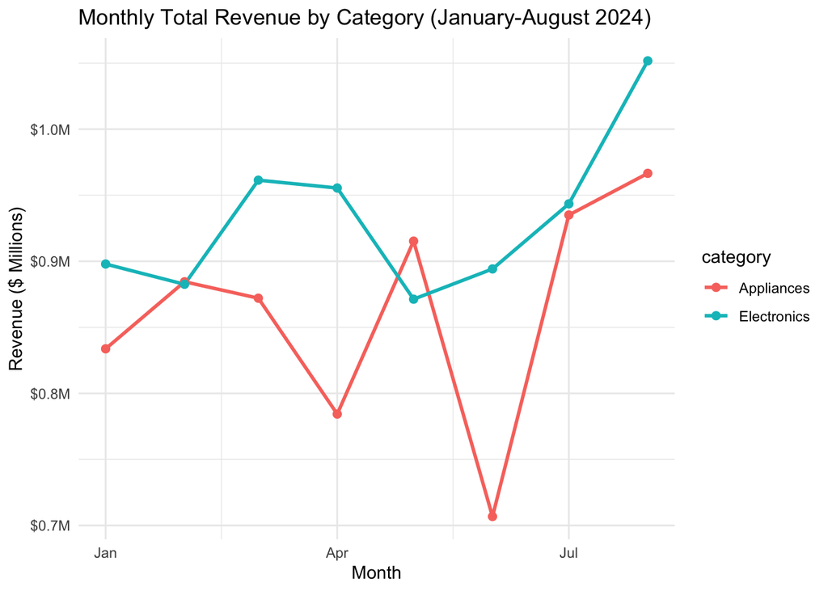

```r
ggplot(walmart_month_clean, aes(x = month, y = total_revenue, color = category)) +
  geom_line(linewidth = 1) +
  geom_point(size = 2) +
  scale_y_continuous(
    labels = scales::label_number(scale = 1e-6, suffix = "M", prefix = "$")
  ) +
  labs(title = "Monthly Total Revenue by Category (January-August 2024)",
       x = "Month",
       y = "Revenue ($ Millions)") +
  theme_minimal()
```

Final Monthly Revenue Comparison (January–August 2024)

Overall, the time-series results reinforce earlier statistical findings: differences between categories are modest and appear to be driven primarily by transaction volume rather than meaningful differences in average spending behavior per transaction.